# Analysis of Severe Weather Events Impacts

jnabonne

7/17/2018

## About

This document computes the answer to the [assignment #2 of Reproducible Research course](https://www.coursera.org/learn/reproducible-research/peer/OMZ37/course-project-2).

### Dataset and corresponding Documentation

The dataset for this exercice available [here](https://d396qusza40orc.cloudfront.net/repdata%2Fdata%2FStormData.csv.bz2).

There is also two documents to better understand its content:

- [NWS Documentation](https://d396qusza40orc.cloudfront.net/repdata%2Fpeer2_doc%2Fpd01016005curr.pdf)
- [additional FAQ](https://d396qusza40orc.cloudfront.net/repdata%2Fpeer2_doc%2FNCDC%20Storm%20Events-FAQ%20Page.pdf)

### Synopsis of the Analysis

The main objective of this analysis is to understand the possible impacts (economic and public health) of server weather events.  
Two main questions were asked :

1. which types of events are most harmful to population health?
2. which types of events have the greatest economic consequences?

This analysis starts by downloading a dataset from the U.S. National Oceanic and Atmospheric Administration’s (NOAA) storm database containing characteristics of major storms and weather events in the US (time, location, impacts estimation).

The data are then cleaned to only conserve interesting measures and in adequate format for manipulation and display.

Some new tables presenting aggregated results are the created giving for each type of events their number of occurences, victims and damages amount.

The Analysis ends by displaying some graphics showing evidence that tornados and flood are respectively the worst events in term of human victims and economical damages.

## Data Processing

First we load the libraries used for this analysis

```r
    library(ggplot2)
    library(dplyr)
```

Then we download the dataset from the internet.  
No check on the already existing presence of the file is done, this to ensure that we always work on the latest available version of the dataset.

```r
    # DOWNLOADING DATASET (EACH TIME TO GET ITS LATEST VERSION)
    file_url  <- "https://d396qusza40orc.cloudfront.net/repdata%2Fdata%2FStormData.csv.bz2"
    file_path <- "StormData.csv.bz2"
    download.file(file_url, destfile=file_path, method="curl")
```

The dataset is then loaded

```r
    # Reading (and unzipping on-the-fly) the DATASET
    sdata <- read.csv("StormData.csv.bz2")
#   sdata <- read.csv("StormData.csv.bz2", nrows=30000) # only to speed tests ;)
```

Then some processing are done to the dataset to ease the rest of the analysis.

First we change the exponent factors to be applied to property and crop damages by correct numeric values. Following some reading on the internet (especially [this post](https://rstudio-pubs-static.s3.amazonaws.com/58957_37b6723ee52b455990e149edde45e5b6.html)) the following matching as been performed

| symbol | exponent value |
| --- | --- |
| numeric | 10 |
| h or H | 100 |
| t or T | 1000 |
| k or K | 1000 |
| m or M | 1.000.000 |
| b or B | 1.000.000.000 |
| + | 1 |
| all others | 0 |

These exponent values are then used to redress property and crop damages.

```r
    # Mathcing exponantial factors with correct numeric values
    sdata <- mutate(sdata, CROPDMGEXP=ifelse(CROPDMGEXP %in% c('h','H'), 100,
                            ifelse(CROPDMGEXP %in% c('t','T','k','K'), 1000,
                            ifelse(CROPDMGEXP %in% c('m','M'), 1000000,
                            ifelse(CROPDMGEXP %in% c('b','B'), 1000000000,
                            ifelse(CROPDMGEXP %in% 0:9, 10,
                            ifelse(CROPDMGEXP == '+', 1, 0)))))))
    sdata <- mutate(sdata, PROPDMGEXP=ifelse(PROPDMGEXP %in% c('h','H'), 100,
                            ifelse(PROPDMGEXP %in% c('t','T','k','K'), 1000,
                            ifelse(PROPDMGEXP %in% c('m','M'), 1000000,
                            ifelse(PROPDMGEXP %in% c('b','B'), 1000000000,
                            ifelse(PROPDMGEXP %in% 0:9, 10,
                            ifelse(PROPDMGEXP == '+', 1, 0)))))))
    # Computing final damages amount from corresponding exponential factors
    sdata <- mutate(sdata,PROPDMG=PROPDMG*PROPDMGEXP,CROPDMG=CROPDMG*CROPDMGEXP)
```

The dataset is the cleaned by removing unusefull columns.  
The dates, even if not very used in this analyis (kept to allow playing with the data set in eda mode) are casted correctly to be more easily manageable.

```r
    # Keeping only interresting data
    sdata <- subset(sdata, select=c("EVTYPE",   "BGN_DATE", "FATALITIES",
                                    "INJURIES", "PROPDMG",  "CROPDMG"))

    # Casting dates correctly (date is here optional and was kept for tests)
    sdata$BGN_DATE <- as.Date(sdata$BGN_DATE, "%m/%d/%Y %H:%M:%S")
    #sd1 <- sdata %>% group_by(year(BGN_DATE), EVTYPE) # requires lubridate lib
```

Finally, the dataset is grouped by event type (using the `dplyr` library) and summarized creating totals for the interesting measures:

- nb of occurences
- total victims, with subtotal per injuries and fatalities
- total damages, with subtotal for property and crop damages

To get plots that can easily be read by humans, we only kept the top10 events (in term of occurences, victims and damages) otherwise we would get graphics with hundreds of variables

```r
    # Grouping data by events and summarizing
    sd2 <- sdata %>% group_by(EVTYPE)
    sd3 <- summarize(sd2, total_events=length(EVTYPE),
                     total_injuries=sum(INJURIES),
                     total_fatalities=sum(FATALITIES),
                     total_victims=sum(INJURIES)+sum(FATALITIES),
                     total_property_damages=sum(PROPDMG),
                     total_crop_damages=sum(CROPDMG),
                     total_damages=sum(PROPDMG)+sum(CROPDMG))

    # Building top10 to get cleaner plots
    top10_events  <- arrange(sd3, desc(sd3$total_events))[1:10,]
    top10_victims <- arrange(sd3, desc(sd3$total_victims))[1:10,]
    top10_damages <- arrange(sd3, desc(sd3$total_damages))[1:10,]
```

## Results

From a pure events based approach we can see on the below graphics **the type of event that occurs most is HAIL.**  
The graphic below shows the most frequent climatic events in the US between 1950 and 2011:

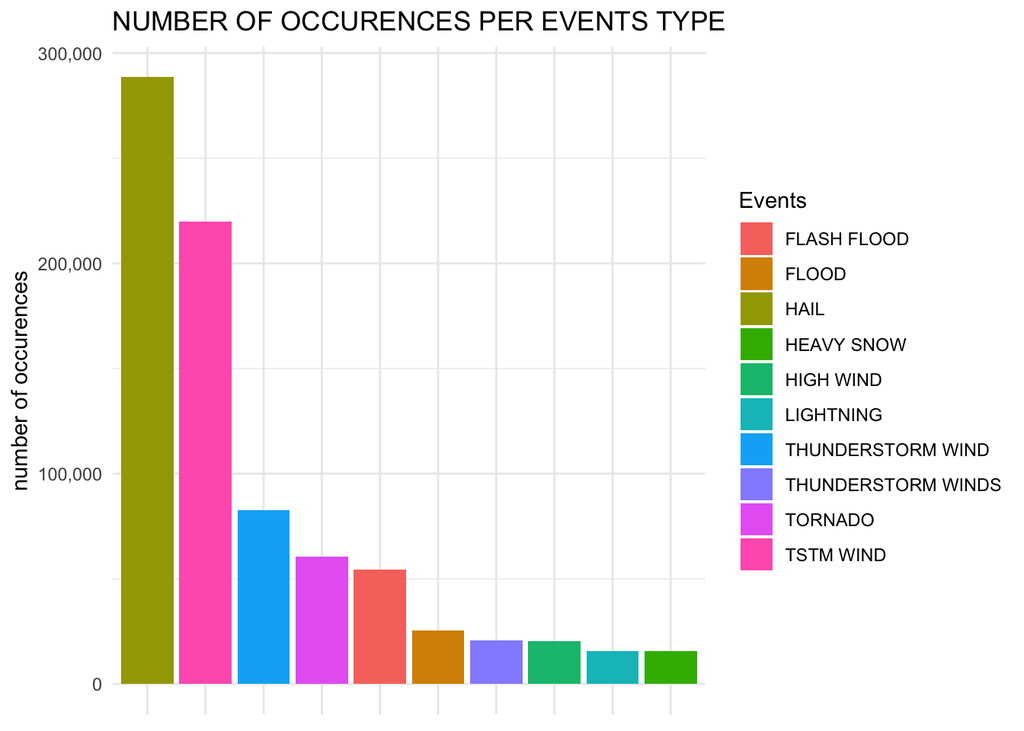

```r
    # ploting nb occurrences / events type
    g <- ggplot(data=top10_events,
            aes(x=reorder(EVTYPE, -total_events), y=total_events, fill=EVTYPE))
    # printing plot with adequate legends and scaling
    g + geom_bar(stat="identity") + theme_minimal() +
    ggtitle("NUMBER OF OCCURENCES PER EVENTS TYPE") + labs(fill="Events") +
    scale_y_continuous(name="number of occurences", labels = scales::comma) +
    theme(axis.title.x=element_blank(), axis.text.x=element_blank(),
                                                axis.ticks.x=element_blank())
```

This does not represent a list of the most dangerous climatic events. We should take some criteria to investigate more about these catastrophic events…

### Victims based approach

But if we base our analysis on the number of victims the result is quite different; **the worst event in terms of human victims is TORNADO.**  
Note that have been summed here injuries and fatalities (even if deaths could arguably count more) as it is difficult to create a scale between these two.

The table below displays a top10 of victims per event type:

```r
    subset(arrange(sd3, desc(sd3$total_victims))[1:10,], select=c("EVTYPE",
        "total_events", "total_injuries", "total_fatalities", "total_victims"))
```

```
## # A tibble: 10 x 5
##    EVTYPE       total_events total_injuries total_fatalities total_victims
##    <fct>               <int>          <dbl>            <dbl>         <dbl>
##  1 TORNADO             60652          91346             5633         96979
##  2 EXCESSIVE H…         1678           6525             1903          8428
##  3 TSTM WIND          219940           6957              504          7461
##  4 FLOOD               25326           6789              470          7259
##  5 LIGHTNING           15754           5230              816          6046
##  6 HEAT                  767           2100              937          3037
##  7 FLASH FLOOD         54277           1777              978          2755
##  8 ICE STORM            2006           1975               89          2064
##  9 THUNDERSTOR…        82563           1488              133          1621
## 10 WINTER STORM        11433           1321              206          1527
```

The graphic below shows a top10 of the worst events in terms of victims:

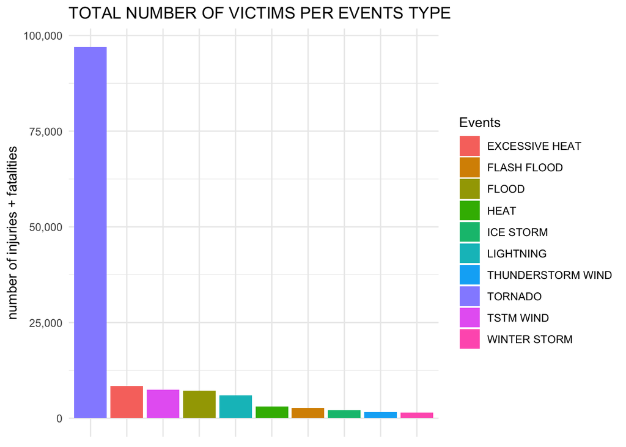

```r
    # ploting nb victims / events type
    g <- ggplot(data=top10_victims,
        aes(x=reorder(EVTYPE, -total_victims), y=total_victims, fill=EVTYPE))
    # printing plot with adequate legends and scaling
    g + geom_bar(stat="identity") + theme_minimal() +
    ggtitle("TOTAL NUMBER OF VICTIMS PER EVENTS TYPE") + labs(fill="Events") +
    scale_y_continuous(name="number of injuries + fatalities",
                                                    labels = scales::comma) +
    theme(axis.title.x=element_blank(), axis.text.x=element_blank(),
                                                axis.ticks.x=element_blank())
```

### Economic based approach

Now from an economic point of view, the result is again different with **FLOOD arriving first in term of damages amount.**  
As for victims, both property and crop damages have been added together to get these results.

The table below displays a top10 of economic damages per event type:

```r
    subset(arrange(sd3, desc(sd3$total_damages))[1:10,], select=c("EVTYPE",
                                    "total_events", "total_property_damages",
                                    "total_crop_damages", "total_damages"))
```

```
## # A tibble: 10 x 5
##    EVTYPE    total_events total_property_d… total_crop_dama… total_damages
##    <fct>            <int>             <dbl>            <dbl>         <dbl>
##  1 FLOOD            25326      144657709800       5661968450  150319678250
##  2 HURRICAN…           88       69305840000       2607872800   71913712800
##  3 TORNADO          60652       56937162897        414954710   57352117607
##  4 STORM SU…          261       43323536000             5000   43323541000
##  5 HAIL            288661       15732269877       3025954650   18758224527
##  6 FLASH FL…        54277       16140815011       1421317100   17562132111
##  7 DROUGHT           2488        1046106000      13972566000   15018672000
##  8 HURRICANE          174       11868319010       2741910000   14610229010
##  9 RIVER FL…          173        5118945500       5029459000   10148404500
## 10 ICE STORM         2006        3944928310       5022113500    8967041810
```

The graphic below shows the 10 worst events in terms of economic damages.

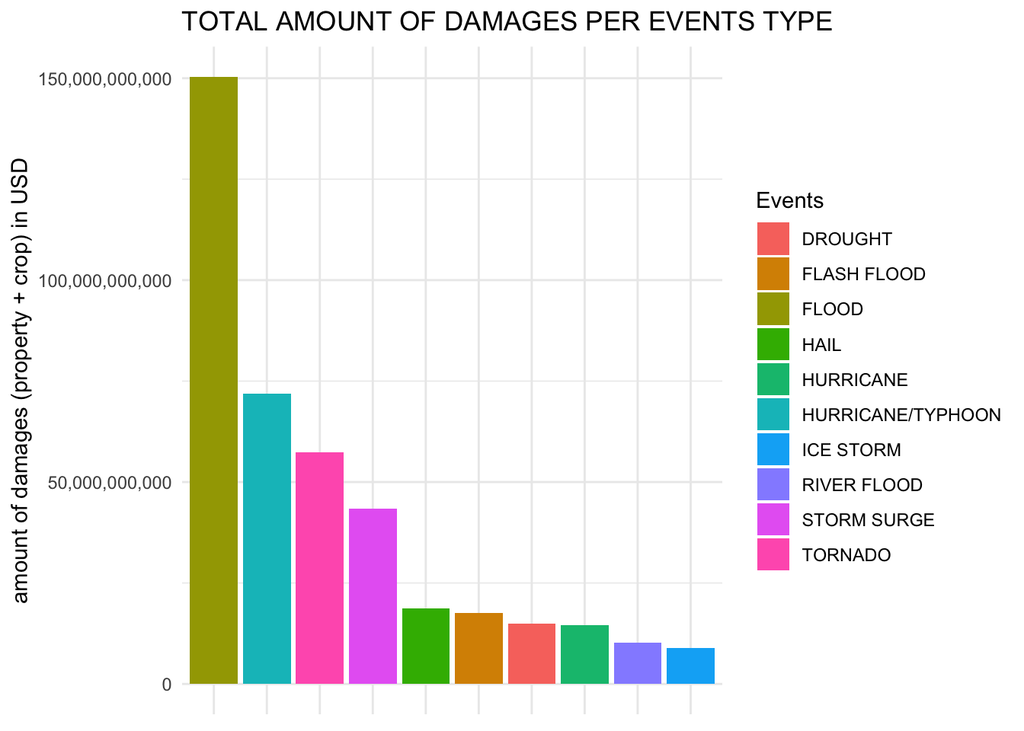

```r
    # ploting damages / events type
    g <- ggplot(data=top10_damages,
        aes(x=reorder(EVTYPE, -total_damages), y=total_damages, fill=EVTYPE))
    # printing plot with adequate legends and scaling
    g + geom_bar(stat="identity") + theme_minimal() +
    ggtitle("TOTAL AMOUNT OF DAMAGES PER EVENTS TYPE") + labs(fill="Events") +
    scale_y_continuous(name="amount of damages (property + crop) in USD",
                                                    labels = scales::comma) +
    theme(axis.title.x=element_blank(), axis.text.x=element_blank(),
                                                axis.ticks.x=element_blank())
```

This is the end, thanks for reading until it!